# Experimento de huecos: ¿cuánta falta de datos aguanta una curva anual?

**Pregunta.** La curva anual de una estación se ajusta solo con los días observados (mínimos cuadrados sobre B-splines), así que un año incompleto igual produce una curva. ¿Desde cuándo esa curva deja de ser confiable? La respuesta fija el umbral de cobertura, el hueco máximo y si hace falta imputar.

**Diseño.**

1. Se toman los estación-años del Valle **completos** (365 días tras quitar el 29-feb) del periodo de **entrenamiento** (1981–1995). Su curva con todos los días es la *verdad*.
2. Se les quitan días de tres maneras: (A) un hueco continuo de largo L; (B) días sueltos al azar (fracción f); (C) **el patrón real de faltantes** de un estación-año incompleto, trasplantado a un año completo.
3. Se vuelve a ajustar la curva con los días que quedan y se compara con la verdad.

**Escala del error.** Se mide el error de la curva (RMSE en mm/día sobre los 365 días) **dividido por la variabilidad interanual de esa estación**: cuánto difieren normalmente sus años entre sí. Un error relativo de 0.2 significa que el hueco mueve la curva una quinta parte de lo que se mueve de un año a otro. Por debajo de ~0.25 el hueco es pequeño frente a la señal que queremos estudiar.

**Base.** B-splines cúbicas con nodos equiespaciados en 1–365, igual que el flujo actual: K = 8 (el K vigente) y, como sensibilidad, K = 12. Al rehacer la selección de K se puede repetir el experimento.

```r
library(data.table)
library(ggplot2)
library(splines)
theme_set(theme_minimal(base_size = 11))
set.seed(20261112)
dir.create("analisis_R/salidas/huecos", showWarnings = FALSE, recursive = TRUE)
out <- function(x, f) fwrite(x, file.path("analisis_R/salidas/huecos", f))
```

# 1 Datos

```r
est <- fread("analisis_R/salidas/estaciones_metadatos.csv", colClasses = list(character = "codigo"))
valle <- est[departamento == "Valle del Cauca", codigo]
crudo <- rbind(fread("P_1980_1990.csv"), fread("P_1991_2003.csv"))
crudo[, codigo := as.character(STATION_ID)]
d <- crudo[YEAR %between% c(1981, 2003) & codigo %in% valle & !(MONTH == 2 & DAY == 29)]
rm(crudo); invisible(gc())
d[, fecha := as.IDate(sprintf("%d-%02d-%02d", YEAR, MONTH, DAY))]
d[, doy := yday(fecha) - (MONTH > 2 & YEAR %% 4 == 0)]   # 1..365 sin 29-feb
stopifnot(d[, all(doy %between% c(1, 365))])
# Matriz estación-año × día (NA = sin dato) para años con algún dato
d[, clave := paste(codigo, YEAR, sep = "_")]
Ytodo <- dcast(d, clave ~ doy, value.var = "VALUE")
claves <- Ytodo$clave; Ytodo <- as.matrix(Ytodo[, -1]); rownames(Ytodo) <- claves
info <- data.table(clave = claves, codigo = sub("_.*", "", claves), anio = as.integer(sub(".*_", "", claves)))
info[, n_obs := rowSums(!is.na(Ytodo))]
completos <- info[n_obs == 365 & anio <= 1995]
completos[, .(estacion_anios_completos = .N, estaciones = uniqueN(codigo))]
```

| estacion_anios_completos | estaciones |
| --- | --- |
| 1960 | 198 |

```r
base <- function(K) {
  nodos <- c(rep(1, 3), seq(1, 365, length.out = K - 2), rep(365, 3))
  splineDesign(nodos, 1:365, ord = 4)
}
ajustar <- function(y, obs, Phi) {          # y: 365 valores; obs: lógico
  P <- Phi[obs, , drop = FALSE]
  A <- crossprod(P)
  if (rcond(A) < 1e-10) return(rep(NA_real_, 365))   # base no identificable
  drop(Phi %*% solve(A, crossprod(P, y[obs])))
}
Ycomp <- Ytodo[completos$clave, ]
# Variabilidad interanual por estación (con su curva completa)
escala <- function(Phi) {
  Xref <- t(apply(Ycomp, 1, ajustar, obs = rep(TRUE, 365), Phi = Phi))
  dt <- data.table(codigo = completos$codigo, i = seq_len(nrow(Xref)))
  sd_int <- dt[, .(sd = if (.N >= 3) sqrt(mean(sweep(Xref[i, , drop = FALSE], 2, colMeans(Xref[i, , drop = FALSE]))^2)) else NA_real_),
               by = codigo]
  list(X = Xref, sd = sd_int)
}
```

```r
Ks <- c(8, 12)
ref <- lapply(Ks, function(K) { Phi <- base(K); c(list(Phi = Phi), escala(Phi)) }); names(ref) <- Ks
rbindlist(lapply(Ks, function(K) ref[[as.character(K)]]$sd[, .(K, estaciones = sum(!is.na(sd)),
                                                               sd_interanual_mediana_mm_dia = median(sd, na.rm = TRUE))]))
```

| K | estaciones | sd_interanual_mediana_mm_dia |
| --- | --- | --- |
| 8 | 182 | 1.602087 |
| 12 | 182 | 1.914872 |

```r
# Error relativo de una curva con máscara 'obs' frente a su verdad
err_rel <- function(i, obs, K) {
  r <- ref[[as.character(K)]]
  xh <- ajustar(Ycomp[i, ], obs, r$Phi)
  rmse <- sqrt(mean((xh - r$X[i, ])^2))
  sd <- r$sd[codigo == completos$codigo[i], sd]
  c(rmse = rmse, rel = rmse / sd)
}
usar <- which(completos$codigo %in% ref[["8"]]$sd[!is.na(sd), codigo])   # estaciones con ≥3 años completos
length(usar)
```

```
## [1] 1939
```

# 2 A. Un hueco continuo

```r
Ls <- c(1, 3, 5, 7, 10, 15, 20, 30, 45, 60, 75, 90)
A <- rbindlist(lapply(Ks, function(K) rbindlist(lapply(Ls, function(L) {
  rbindlist(lapply(usar, function(i) {
    ini <- sample.int(365 - L + 1, 1); obs <- rep(TRUE, 365); obs[ini:(ini + L - 1)] <- FALSE
    e <- err_rel(i, obs, K)
    data.table(K, L, ini, rmse = e[["rmse"]], rel = e[["rel"]])
  }))
}))))
out(A, "A_hueco_continuo.csv")
A[, .(fallas = sum(is.na(rel)), p50 = median(rel, na.rm = TRUE), p90 = quantile(rel, .9, na.rm = TRUE),
      p99 = quantile(rel, .99, na.rm = TRUE)), by = .(K, L)]
```

| K | L | fallas | p50 | p90 | p99 |
| --- | --- | --- | --- | --- | --- |
| 8 | 1 | 0 | 0.0157702 | 0.0438747 | 0.1925932 |
| 8 | 3 | 0 | 0.0389180 | 0.1123394 | 0.3134144 |
| 8 | 5 | 0 | 0.0588637 | 0.1605360 | 0.3783304 |
| 8 | 7 | 0 | 0.0744129 | 0.1990872 | 0.4665670 |
| 8 | 10 | 0 | 0.0924092 | 0.2632903 | 0.5617541 |
| 8 | 15 | 0 | 0.1205254 | 0.3532057 | 0.6879745 |
| 8 | 20 | 0 | 0.1636794 | 0.4437065 | 0.8824122 |
| 8 | 30 | 0 | 0.2336087 | 0.6009516 | 1.3328026 |
| 8 | 45 | 0 | 0.3525045 | 0.9107699 | 2.3314824 |
| 8 | 60 | 0 | 0.4821206 | 1.3547009 | 3.7670305 |
| 8 | 75 | 8 | 0.6386275 | 1.7627096 | 5.2489222 |
| 8 | 90 | 10 | 0.8979112 | 2.6566473 | 13.3895939 |
| 12 | 1 | 0 | 0.0161565 | 0.0452154 | 0.1682365 |
| 12 | 3 | 0 | 0.0401184 | 0.1191112 | 0.3006005 |
| 12 | 5 | 0 | 0.0576117 | 0.1704111 | 0.3794419 |
| 12 | 7 | 0 | 0.0810726 | 0.2272722 | 0.4679944 |
| 12 | 10 | 0 | 0.1007589 | 0.2875073 | 0.5634980 |
| 12 | 15 | 0 | 0.1449622 | 0.4152337 | 0.7337166 |
| 12 | 20 | 0 | 0.1877026 | 0.5279316 | 1.2809193 |
| 12 | 30 | 0 | 0.3157668 | 0.8489960 | 1.9690812 |
| 12 | 45 | 10 | 0.5623620 | 1.4987402 | 4.0526669 |
| 12 | 60 | 14 | 0.9381784 | 2.6619834 | 7.1550469 |
| 12 | 75 | 16 | 1.6191415 | 5.3462404 | 16.7130998 |
| 12 | 90 | 29 | 3.0714965 | 10.6860926 | 33.3701990 |

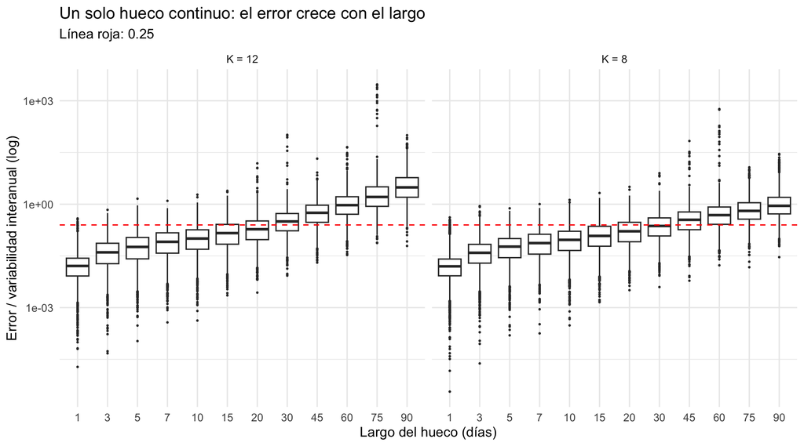

```r
ggplot(A[!is.na(rel)], aes(factor(L), rel)) + geom_boxplot(outlier.size = .3) +
  facet_wrap(~paste("K =", K)) + geom_hline(yintercept = .25, colour = "red", linetype = 2) +
  scale_y_log10() +
  labs(x = "Largo del hueco (días)", y = "Error / variabilidad interanual (log)",
       title = "Un solo hueco continuo: el error crece con el largo",
       subtitle = "Línea roja: 0.25")
```

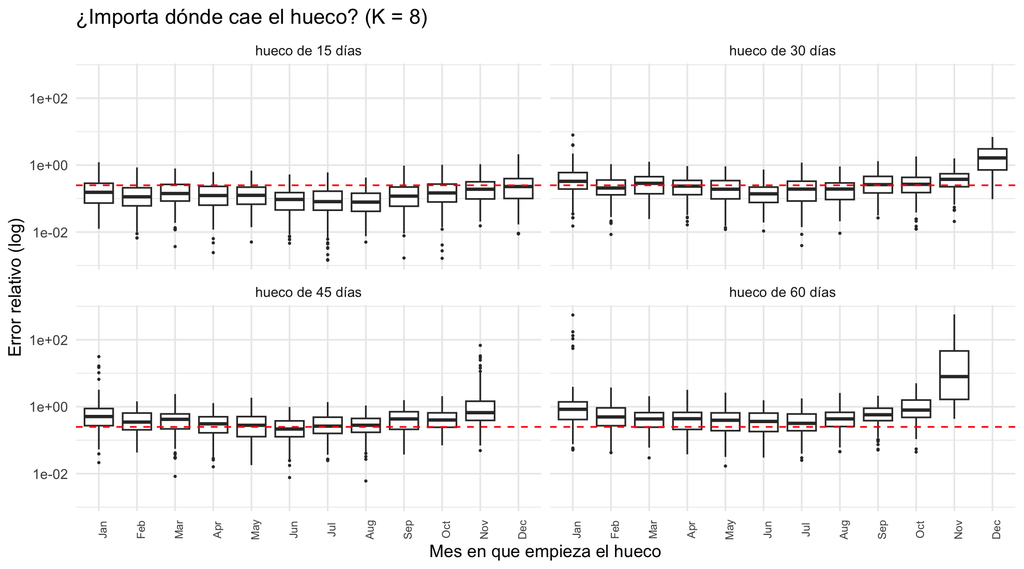

```r
A[, mes_ini := cut(ini, breaks = c(0, cumsum(c(31, 28, 31, 30, 31, 30, 31, 31, 30, 31, 30, 31))), labels = month.abb)]
ggplot(A[K == 8 & L %in% c(15, 30, 45, 60) & !is.na(rel)], aes(mes_ini, rel)) + geom_boxplot(outlier.size = .3) +
  facet_wrap(~paste("hueco de", L, "días")) + scale_y_log10() +
  geom_hline(yintercept = .25, colour = "red", linetype = 2) +
  labs(x = "Mes en que empieza el hueco", y = "Error relativo (log)",
       title = "¿Importa dónde cae el hueco? (K = 8)") +
  theme(axis.text.x = element_text(angle = 90, size = 7))
```

# 3 B. Días sueltos al azar

```r
fs <- c(.01, .02, .05, .10, .15, .20, .30, .40, .50)
B <- rbindlist(lapply(Ks, function(K) rbindlist(lapply(fs, function(f) {
  rbindlist(lapply(usar, function(i) {
    obs <- rep(TRUE, 365); obs[sample.int(365, round(f * 365))] <- FALSE
    e <- err_rel(i, obs, K); data.table(K, f, rmse = e[["rmse"]], rel = e[["rel"]])
  }))
}))))
out(B, "B_dias_sueltos.csv")
B[, .(p50 = median(rel, na.rm = TRUE), p90 = quantile(rel, .9, na.rm = TRUE)), by = .(K, pct_faltante = 100 * f)]
```

| K | pct_faltante | p50 | p90 |
| --- | --- | --- | --- |
| 8 | 1 | 0.0457855 | 0.1353016 |
| 8 | 2 | 0.0725689 | 0.1696267 |
| 8 | 5 | 0.1434215 | 0.2819015 |
| 8 | 10 | 0.2228590 | 0.3867324 |
| 8 | 15 | 0.2975438 | 0.4891671 |
| 8 | 20 | 0.3608536 | 0.5864923 |
| 8 | 30 | 0.4790714 | 0.7675696 |
| 8 | 40 | 0.6069192 | 0.9606061 |
| 8 | 50 | 0.7447538 | 1.1633309 |
| 12 | 1 | 0.0484620 | 0.1384101 |
| 12 | 2 | 0.0740037 | 0.1829882 |
| 12 | 5 | 0.1472341 | 0.2794339 |
| 12 | 10 | 0.2349222 | 0.3910831 |
| 12 | 15 | 0.3126173 | 0.4914393 |
| 12 | 20 | 0.3766117 | 0.5766448 |
| 12 | 30 | 0.5043839 | 0.7674542 |
| 12 | 40 | 0.6377273 | 0.9644871 |
| 12 | 50 | 0.7871954 | 1.1533401 |

# 4 C. Patrones reales de faltantes

Cada estación-año real incompleto (≥40 % de días) aporta su máscara de faltantes; se aplica a 5 años completos elegidos al azar.

```r
mx_hueco <- function(obs) { r <- rle(!obs); if (any(r$values)) max(r$lengths[r$values]) else 0L }
inc <- info[n_obs < 365 & n_obs >= 0.4 * 365]
mask <- !is.na(Ytodo[inc$clave, , drop = FALSE])
inc[, `:=`(pct = 100 * n_obs / 365, hueco_max = apply(mask, 1, mx_hueco))]
C <- rbindlist(lapply(Ks, function(K) rbindlist(lapply(seq_len(nrow(inc)), function(m) {
  rbindlist(lapply(sample(usar, 5), function(i) {
    e <- err_rel(i, mask[m, ], K)
    data.table(K, mascara = inc$clave[m], pct = inc$pct[m], hueco_max = inc$hueco_max[m],
               rmse = e[["rmse"]], rel = e[["rel"]])
  }))
}))))
out(C, "C_mascaras_reales.csv")
inc[, .(mascaras = .N, pct_mediana = median(pct), hueco_max_mediana = median(hueco_max))]
```

| mascaras | pct_mediana | hueco_max_mediana |
| --- | --- | --- |
| 912 | 96.57534 | 8 |

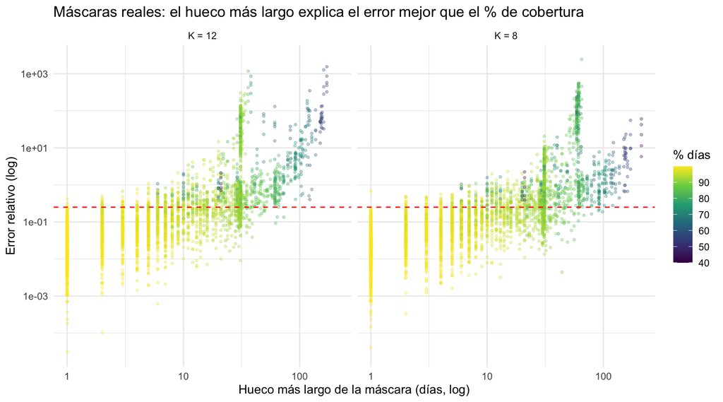

```r
ggplot(C[!is.na(rel)], aes(hueco_max, rel, colour = pct)) + geom_point(alpha = .3, size = .8) +
  facet_wrap(~paste("K =", K)) + scale_x_log10() + scale_y_log10() +
  geom_hline(yintercept = .25, colour = "red", linetype = 2) + scale_colour_viridis_c(name = "% días") +
  labs(x = "Hueco más largo de la máscara (días, log)", y = "Error relativo (log)",
       title = "Máscaras reales: el hueco más largo explica el error mejor que el % de cobertura")
```

```r
m <- lm(log(rel) ~ log1p(hueco_max) + pct, data = C[K == 8 & !is.na(rel)])
summary(m)$coefficients
```

```
##                     Estimate  Std. Error     t value      Pr(>|t|)
## (Intercept)      -0.27088352 0.432068492  -0.6269458  5.307294e-01
## log1p(hueco_max)  1.09350225 0.028731742  38.0590303 5.605450e-272
## pct              -0.04454881 0.004056839 -10.9811611  1.132130e-27
```

```r
cat("R² con solo hueco_max:", round(summary(lm(log(rel) ~ log1p(hueco_max), C[K == 8 & !is.na(rel)]))$r.squared, 3),
    "| R² con solo pct:", round(summary(lm(log(rel) ~ pct, C[K == 8 & !is.na(rel)]))$r.squared, 3), "\n")
```

```
## R² con solo hueco_max: 0.585 | R² con solo pct: 0.455
```